# Uber Data Analysis

ERICK@Guru

## Data Science Project in R – Uber Data Analysis Project

we will analyze the Uber Pickups in New York City dataset. This is more of a data visualization project that will guide you towards using the ggplot2 library for understanding the data and for developing an intuition for understanding the customers who avail the trips. Talking about our Uber data analysis project, data storytelling is an important component of Machine Learning through which companies are able to understand the background of various operations. With the help of visualization, companies can avail the benefit of understanding the complex data and gain insights that would help them to craft decisions. You will learn how to implement the ggplot2 on the Uber Pickups dataset and at the end, master the art of data visualization in R. Uber Dataset

### IMPORT ESSENTIAL LIBRARIES

```r
library(tidyverse)#data cleanining/manipulation/wrangling
library(ggplot2)#backbone of this project
library(lubridate)#manipulate date variable
library(ggthemes)#add-on to ggplot2create extra themes
library(DT)# help to interface with javascript
library(dplyr)#data manipulation/wrangling
library(tidyr)#help tidy your data
library(scales)#map data into correct scales
```

## 1.) Creating Vector of Colors to be implemented in our plots.

```r
colors <- c(
   "#f5e840", "#0683c9", "#e075b0"
)
```

## 2.) Reading the Data into their designated variables

```r
#import datasets
april <- read_csv("uber-raw-apr data.csv")
may <- read_csv("uber-raw-data-may14.csv")
june <- read_csv("uber-raw-data-jun14.csv")
july <- read_csv("uber-raw-data-jul14.csv")
august <-read_csv("uber-raw-data-aug14.csv")
sept <- read_csv("uber-raw-data-sep14.csv")
```

```r
#Manipulating Date variable into correct format
april$`Date/Time` <- mdy_hm(april$`Date/Time`)
may$`Date/Time` <- mdy_hms(may$`Date/Time`)
june$`Date/Time` <- mdy_hms(june$`Date/Time`)
july$`Date/Time` <- mdy_hms(july$`Date/Time`)
august$`Date/Time` <- mdy_hms(august$`Date/Time`)
sept$`Date/Time` <- mdy_hms(sept$`Date/Time`)
```

## 3.) Data Manipulation/ EDA

```r
#combining data into one
data_2014 <- rbind(
  april, may, june, july, august,sept
)
head(data_2014)#check the first 6 columns
```

| Date/Time | Lat | Lon | Base |
| --- | --- | --- | --- |
| 2014-04-01 00:11:00 | 40.7690 | -73.9549 | B02512 |
| 2014-04-01 00:17:00 | 40.7267 | -74.0345 | B02512 |
| 2014-04-01 00:21:00 | 40.7316 | -73.9873 | B02512 |
| 2014-04-01 00:28:00 | 40.7588 | -73.9776 | B02512 |
| 2014-04-01 00:33:00 | 40.7594 | -73.9722 | B02512 |
| 2014-04-01 00:33:00 | 40.7383 | -74.0403 | B02512 |

```r
#check missing values
colSums(is.na(data_2014))#no missing values
```

```
## Date/Time       Lat       Lon      Base
##         0         0         0         0
```

```r
sum(is.na(data_2014))#
```

```
## [1] 0
```

```r
#CHECK DATA STRUCTURE
# str(data_2014)
glimpse(data_2014)
```

```
## Rows: 4,534,327
## Columns: 4
## $ `Date/Time` <dttm> 2014-04-01 00:11:00, 2014-04-01 00:17:00, 2014-04-01 00:2…
## $ Lat         <dbl> 40.7690, 40.7267, 40.7316, 40.7588, 40.7594, 40.7383, 40.7…
## $ Lon         <dbl> -73.9549, -74.0345, -73.9873, -73.9776, -73.9722, -74.0403…
## $ Base        <chr> "B02512", "B02512", "B02512", "B02512", "B02512", "B02512"…
```

```r
dim(data_2014)
```

```
## [1] 4534327       4
```

```r
names(data_2014)
```

```
## [1] "Date/Time" "Lat"       "Lon"       "Base"
```

### Lets Create the variables for Day of of the month, hour, day of the week, and the month

```r
data_2014 <- data_2014 %>%
     mutate(
       hour=factor(hour(`Date/Time`)),
       day=factor(day(`Date/Time`)),
       wday=factor(wday(`Date/Time`, label=TRUE)),
       month=factor(month(`Date/Time`, label=TRUE)),
       year=factor(year(`Date/Time`))
     )
head(data_2014, 4)#view the first 4 Rows
```

| Date/Time | Lat | Lon | Base | hour | day | wday | month | year |
| --- | --- | --- | --- | --- | --- | --- | --- | --- |
| 2014-04-01 00:11:00 | 40.7690 | -73.9549 | B02512 | 0 | 1 | Tue | Apr | 2014 |
| 2014-04-01 00:17:00 | 40.7267 | -74.0345 | B02512 | 0 | 1 | Tue | Apr | 2014 |
| 2014-04-01 00:21:00 | 40.7316 | -73.9873 | B02512 | 0 | 1 | Tue | Apr | 2014 |
| 2014-04-01 00:28:00 | 40.7588 | -73.9776 | B02512 | 0 | 1 | Tue | Apr | 2014 |

### Plotting Trips By the Hour of the Day

We group the data by hour of the day to get the summary total, after , we then visualize to get insights:

```r
#hourly Trips
hour_data <- data_2014 %>%
    group_by(hour) %>%
  dplyr::summarise(total=n())

datatable(hour_data)
```

|  | hour | total |
| --- | --- | --- |
| 1 | 0 | 103836 |
| 2 | 1 | 67227 |
| 3 | 2 | 45865 |
| 4 | 3 | 48287 |
| 5 | 4 | 55230 |
| 6 | 5 | 83939 |
| 7 | 6 | 143213 |
| 8 | 7 | 193094 |
| 9 | 8 | 190504 |
| 10 | 9 | 159967 |

[output cut: 14 more lines]

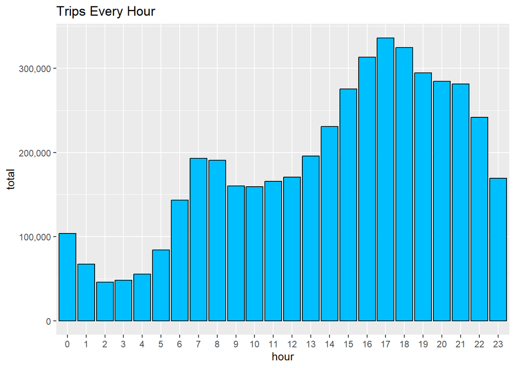

```r
#Trips hourly

ggplot(hour_data, aes(hour, total)) +
       geom_bar(stat = "identity",
           fill = "deepskyblue",
           color = "black") +
          ggtitle("Trips Every Hour") +
          theme(legend.position = "none") +  scale_y_continuous(labels = comma)
```

```r
#month Hour Trips
month_hour <- data_2014 %>%
     group_by(month, hour) %>%
    summarise(Total=n())
DT::datatable(month_hour)
```

|  | month | hour | Total |
| --- | --- | --- | --- |
| 1 | Apr | 0 | 11910 |
| 2 | Apr | 1 | 7769 |
| 3 | Apr | 2 | 4935 |
| 4 | Apr | 3 | 5040 |
| 5 | Apr | 4 | 6095 |
| 6 | Apr | 5 | 9476 |
| 7 | Apr | 6 | 18498 |
| 8 | Apr | 7 | 24924 |
| 9 | Apr | 8 | 22843 |
| 10 | Apr | 9 | 17939 |

[output cut: 134 more lines]

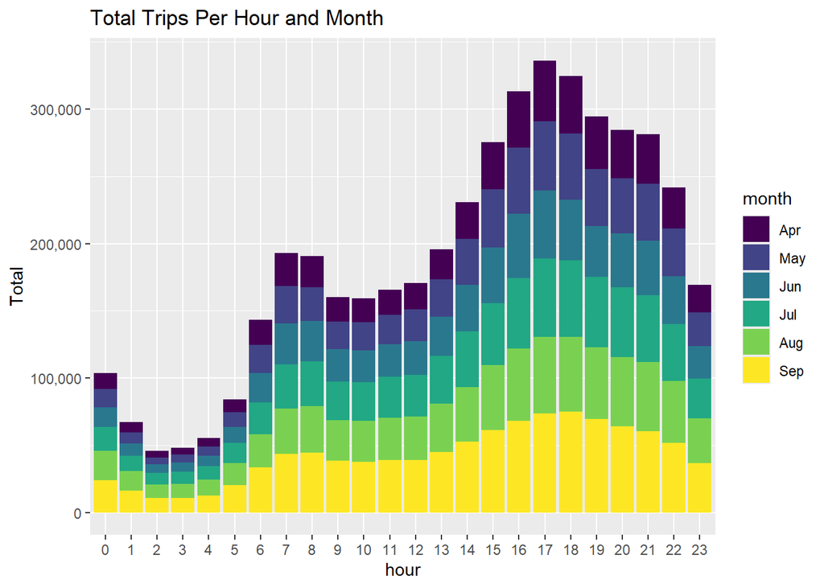

```r
#visualize

month_hour %>%  ggplot(aes(hour, Total, fill=month))+
     geom_bar(stat = 'identity',)+
    ggtitle('Total Trips Per Hour and Month') +
  scale_y_continuous(labels = comma)
```

## Plotting data by trips during every day of the month

In this section of R project, we will learn how to plot our data based on every day of the month. We observe from the resulting visualization that 30th of the month had the highest trips in the year which is mostly contributed by the month of April.

```r
daily_trips <- data_2014 %>%
    group_by(day) %>%
     summarise(Total=n())
 DT::datatable(daily_trips)
```

|  | day | Total |
| --- | --- | --- |
| 1 | 1 | 127430 |
| 2 | 2 | 143201 |
| 3 | 3 | 142983 |
| 4 | 4 | 140923 |
| 5 | 5 | 147054 |
| 6 | 6 | 139886 |
| 7 | 7 | 143503 |
| 8 | 8 | 145984 |
| 9 | 9 | 155135 |
| 10 | 10 | 152500 |

[output cut: 21 more lines]

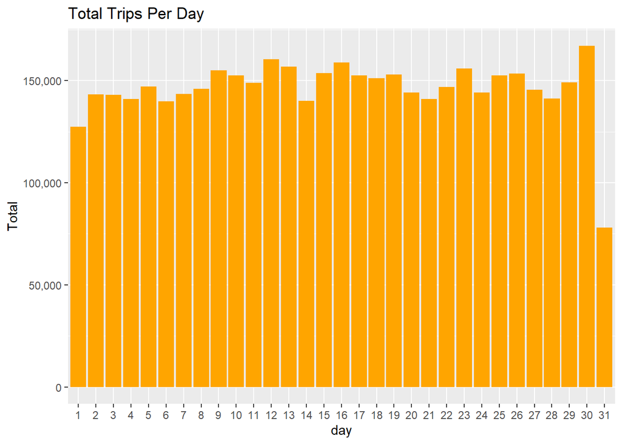

```r
daily_trips %>% ggplot(aes(day, Total)) +
      geom_bar(stat = 'identity', fill='orange')+
     ggtitle('Total Trips Per Day')+
    theme(legend.position = 'none')+
     scale_y_continuous(labels = comma)
```

```r
#day and month total
day_month <- data_2014 %>%
    group_by(month, day) %>%
  summarise(total=n())

DT::datatable(day_month)
```

|  | month | day | total |
| --- | --- | --- | --- |
| 1 | Apr | 1 | 14546 |
| 2 | Apr | 2 | 17474 |
| 3 | Apr | 3 | 20701 |
| 4 | Apr | 4 | 26714 |
| 5 | Apr | 5 | 19521 |
| 6 | Apr | 6 | 13445 |
| 7 | Apr | 7 | 19550 |
| 8 | Apr | 8 | 16188 |
| 9 | Apr | 9 | 16843 |
| 10 | Apr | 10 | 20041 |

[output cut: 173 more lines]

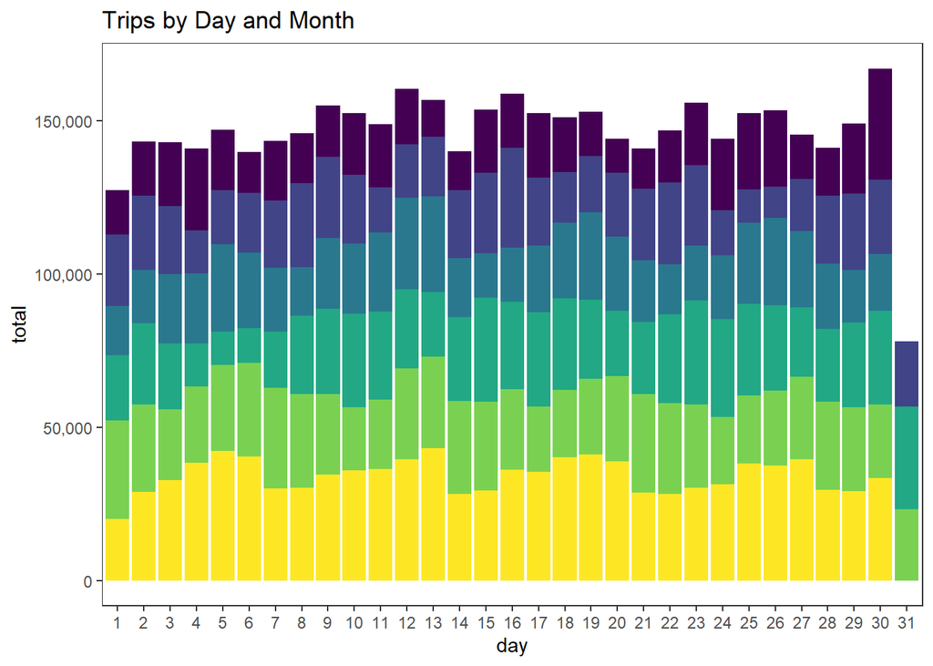

```r
theme_set(theme_test())
day_month %>%
  ggplot(aes(day, total, fill=month))+
     geom_bar(stat='identity')+
     ggtitle('Trips by Day and Month') +
   scale_y_continuous(labels = comma)+
  theme(legend.position = "none")
```

### Number of Trips taking place during months in a year

In this section, we will visualize the number of trips that are taking place each month of the year. In the output visualization, we observe that most trips were made during the month of September. Furthermore, we also obtain visual reports of the number of trips that were made on every day of the week.

```r
month_trips <- data_2014 %>%
  group_by(month) %>%
  summarize(total=n())

DT::datatable(month_trips)
```

|  | month | total |
| --- | --- | --- |
| 1 | Apr | 564516 |
| 2 | May | 652435 |
| 3 | Jun | 663844 |
| 4 | Jul | 796121 |
| 5 | Aug | 829275 |
| 6 | Sep | 1028136 |

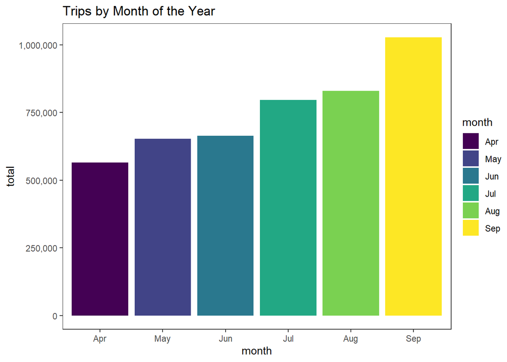

```r
month_trips %>%
  ggplot(aes(month, total, fill=month))+
  geom_bar(stat = 'identity') +
  ggtitle('Trips by Month of the Year')+
  scale_y_continuous(labels = comma)
```

```r
#trips by week day

day_of_week <- data_2014 %>%
  group_by(wday) %>%
  summarise(total=n())

DT::datatable(day_of_week)
```

|  | wday | total |
| --- | --- | --- |
| 1 | Sun | 490180 |
| 2 | Mon | 541472 |
| 3 | Tue | 663789 |
| 4 | Wed | 696488 |
| 5 | Thu | 755145 |
| 6 | Fri | 741139 |
| 7 | Sat | 646114 |

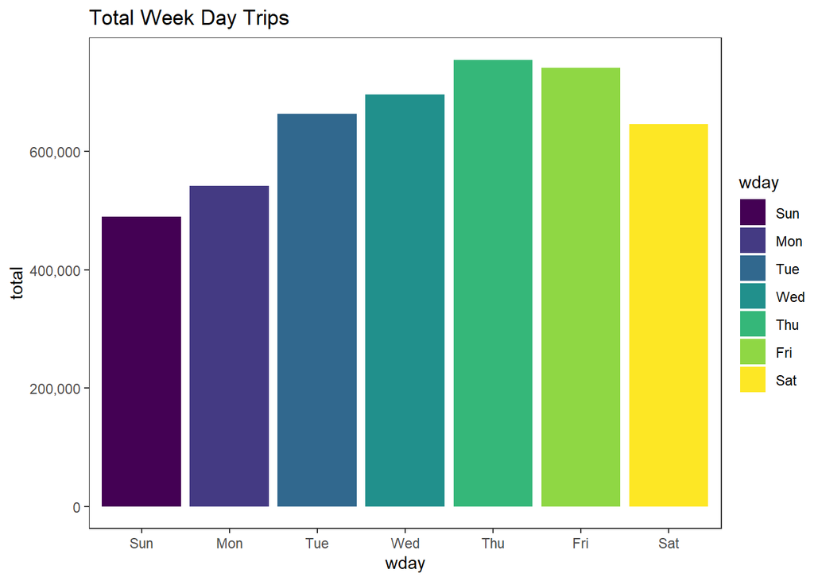

```r
day_of_week %>%
  ggplot(aes(wday, total, fill=wday))+
  geom_bar(stat = 'identity')+
  scale_y_continuous(labels = comma)+
  ggtitle('Total Week Day Trips')
```

### Finding out the number of Trips by bases

```r
base_total <- data_2014 %>%
  group_by(Base) %>%
  summarise(total=n())

DT::datatable(base_total)
```

|  | Base | total |
| --- | --- | --- |
| 1 | B02512 | 205673 |
| 2 | B02598 | 1393113 |
| 3 | B02617 | 1458853 |
| 4 | B02682 | 1212789 |
| 5 | B02764 | 263899 |

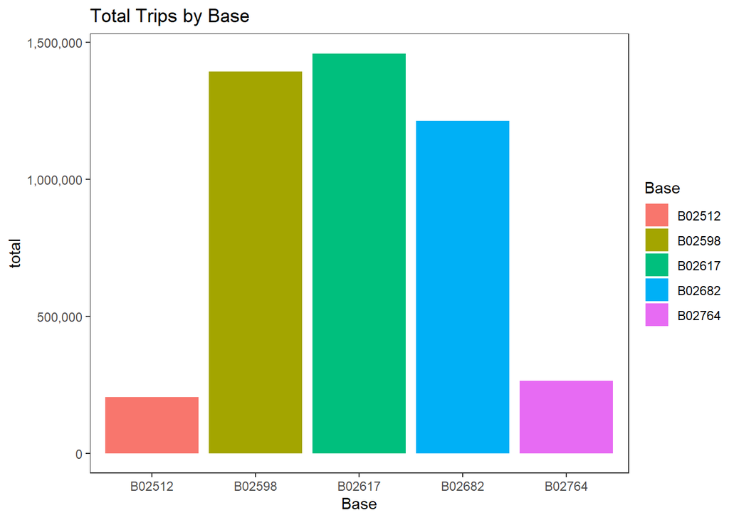

```r
base_total %>%
  ggplot(aes(Base, total, fill=Base))+
  geom_bar(stat = 'identity')+
  ggtitle('Total Trips by Base')+
  scale_y_continuous(labels = comma)
```

### Creating a map visualization of rides in New York

In the final section, we will visualize the rides in New York city by creating a geo-plot that will help us to visualize the rides during 2014 (Apr – Sep) and by the bases in the same period.

```r
min_lat <- 40.5774
max_lat <- 40.9176
min_long <- -74.15
max_long <- -73.7004
```

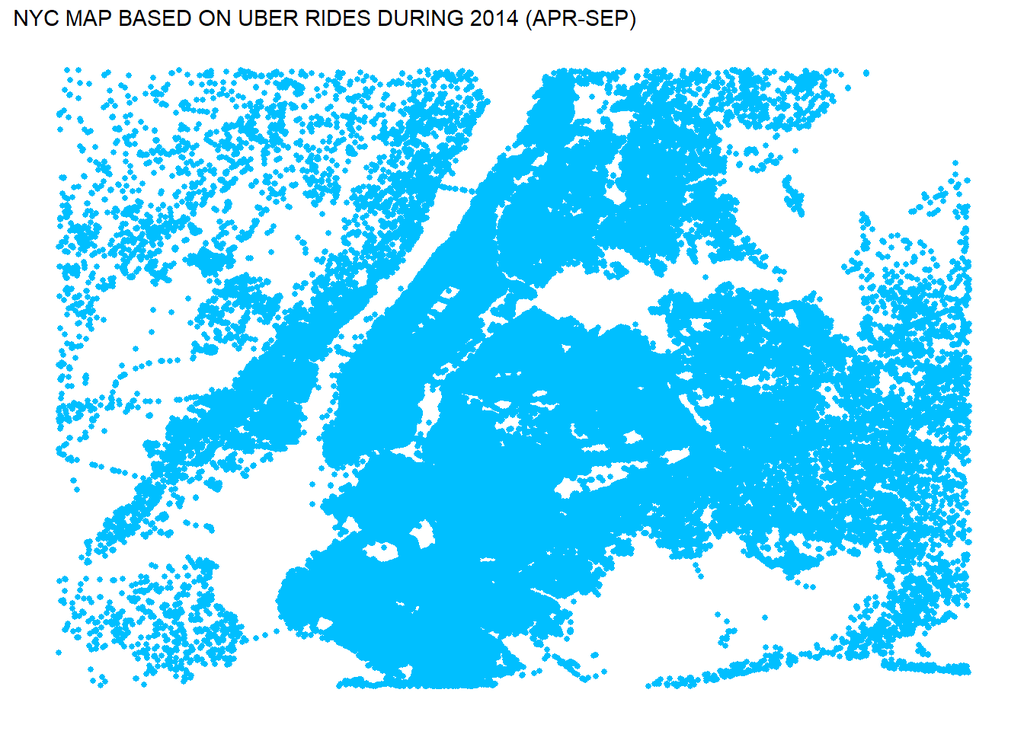

```r
ggplot(data_2014, aes(x=Lon, y=Lat)) +
  geom_point(size=1, color = "deepskyblue") + scale_x_continuous(limits=c(min_long, max_long)) + scale_y_continuous(limits=c(min_lat, max_lat)) + theme_map() +
ggtitle("NYC MAP BASED ON UBER RIDES DURING 2014 (APR-SEP)")
```

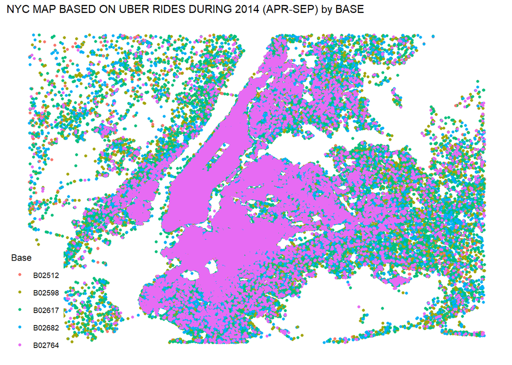

```r
ggplot(data_2014, aes(x=Lon, y=Lat, color = Base)) + geom_point(size=1) +
  scale_x_continuous(limits=c(min_long, max_long)) + scale_y_continuous(limits=c(min_lat, max_lat)) + theme_map() +
  ggtitle("NYC MAP BASED ON UBER RIDES DURING 2014 (APR-SEP) by BASE")
```